# Chapter 11 Building the Regression Model III

Bryan Goodrich

2015-08-08

# Chapter 11 – Building the Regression Model III: Remedial Measures

## Load the data sets

```r
library(MASS)     # rlm
library(car)      # spm, vif
library(bestglm)  # bestglm, regsubsets
library(leaps)    # regsubsets
library(rpart)    # rpart
library(boot)     # boot
data("CH07TA01", package = "ALSM")
data("CH11TA01", package = "ALSM")
data("CH11TA04", package = "ALSM")
data("CH11TA07", package = "ALSM")
data("CH11TA08", package = "ALSM")
data("CH11TA09", package = "ALSM")
data("CH11TA10", package = "ALSM")
data("CH11TA11", package = "ALSM")
data("APPENC04", package = "ALSM")
```

## Input Diastolic Blood Pressure (DBP) data

```r
.data <- CH11TA01
names(.data) <- c("X", "Y")
```

## TABLE 11.1 (p 427)

#### Weighted Least Squares–Blood Pressure Example

```r
fit <- lm(Y ~ X, .data)
w <- fitted(lm(abs(resid(fit)) ~ X, .data))^(-2)
fit <- update(fit, weights = w)

cbind(
  "Subject" = seq(nrow(.data)),
  "Age"     = .data$X,
  "DBP"     = .data$Y,
  "e"       = round(resid(lm(Y ~ X, .data)), 2),
  "|e|"     = round(abs(resid(lm(Y ~ X, .data))), 2),
  "s"       = round(sqrt(1 / w), 4),
  "w"       = round(fit$weights, 5))
```

```
##    Subject Age DBP      e   |e|      s       w
## 1        1  27  73   1.18  1.18  3.801 0.06921
## 2        2  21  66  -2.34  2.34  2.612 0.14656
## 3        3  22  63  -5.92  5.92  2.810 0.12662
## 4        4  24  75   4.92  4.92  3.207 0.09725
## 5        5  25  71   0.34  0.34  3.405 0.08626
## 6        6  23  70   0.50  0.50  3.009 0.11049
## 7        7  20  65  -2.76  2.76  2.414 0.17161
## 8        8  20  70   2.24  2.24  2.414 0.17161
## 9        9  29  79   6.02  6.02  4.197 0.05676
## 10      10  24  72   1.92  1.92  3.207 0.09725
## 11      11  25  68  -2.66  2.66  3.405 0.08626
## 12      12  28  67  -5.40  5.40  3.999 0.06252
## 13      13  26  79   7.76  7.76  3.603 0.07703
## 14      14  38  91  12.80 12.80  5.981 0.02795
```

[output cut: 40 more lines]

## FIGURE 11.1 (p 428)

#### Diagnostic Plots Detecting Unequal Variance–Blood Pressure Example

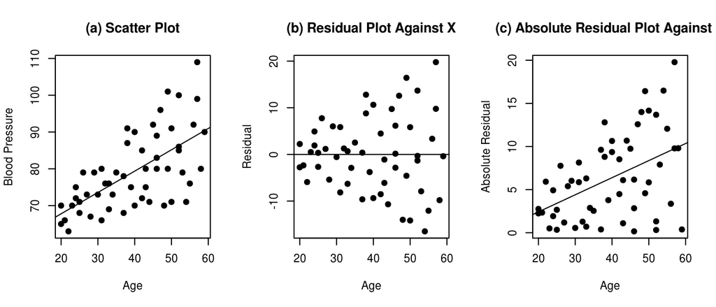

```r
fit <- lm(Y ~ X, .data)
par(mfrow = c(1, 3), pch = 19)

plot(Y ~ X, .data, xlab = "Age", ylab = "Blood Pressure")
title("(a) Scatter Plot")
abline(fit)

plot(resid(fit) ~ X, .data, xlab = "Age", ylab = "Residual")
title("(b) Residual Plot Against X")
abline(0, 0)

plot(abs(resid(fit)) ~ X, .data, xlab = "Age", ylab = "Absolute Residual")
title("(c) Absolute Residual Plot Against X")
abline(lm(abs(resid(fit)) ~ X, .data))
```

## Input Body Fat Data (See Ch. 7)

```r
.data <- CH07TA01
names(.data) <- c("x1", "x2", "x3", "y")
fit <- lm(y ~ x1 + x2 + x3, .data)
```

## TABLE 11.2 and TABLE 11.3 (p 434)

#### Ridge Estimated Standardized Regression Coefficients for Different Biasing Constants c–Body Fat Eample with Three Predictor Variables.

#### VIF Values for Regression Coefficients and R-squared for Different Biasing Constants c–Body Fat Example with Three Predictor Variables.

R has the `lm.ridge` (*MASS*) function, but it produces different results. I’ve tried uses methods in other packages, like *genridge* or *ElemStateLearn*, but the results were pretty much the same.

```r
c <- c(0, .002, .004, .006, .008, .01, .02, .03, .04, .05, .1, .5, 1)
fun1 <- function(c, rxx, rxy) {solve(rxx + c * diag(ncol(rxx)), rxy)}  # (11.34)
fun2 <- function(c, rxx)
{
  bias = solve(rxx + c*diag(ncol(rxx)))
  diag(bias %*% rxx %*% bias)                                          # (11.36)
}

data.frame(lambda = c,
           t(sapply(c, fun1, rxx = cor(.data)[-4, -4], rxy = cor(.data)[-4, 4])),
           VIF = t(sapply(c, fun2, rxx = cor(.data)[-4, -4])))
```

```
##    lambda     x1       x2        x3   VIF.x1   VIF.x2   VIF.x3
## 1   0.000 4.2637 -2.92870 -1.561417 708.8429 564.3434 104.6060
## 2   0.002 1.4407 -0.41129 -0.481273  50.5592  40.4483   8.2797
## 3   0.004 1.0063 -0.02484 -0.314866  16.9816  13.7247   3.3628
## 4   0.006 0.8300  0.13142 -0.247163   8.5033   6.9764   2.1185
## 5   0.008 0.7343  0.21576 -0.210302   5.1472   4.3046   1.6238
## 6   0.010 0.6742  0.26841 -0.187032   3.4855   2.9813   1.3770
## 7   0.020 0.5463  0.37740 -0.136872   1.1026   1.0805   1.0105
## 8   0.030 0.5004  0.41341 -0.118078   0.6257   0.6969   0.9235
## 9   0.040 0.4760  0.43024 -0.107583   0.4528   0.5553   0.8814
## 10  0.050 0.4605  0.43924 -0.100508   0.3705   0.4859   0.8531
## 11  0.100 0.4234  0.44896 -0.081246   0.2515   0.3735   0.7614
## 12  0.500 0.3377  0.37906 -0.029500   0.1540   0.2137   0.4033
## 13  1.000 0.2798  0.31007 -0.005939   0.1071   0.1358   0.2273
```

## FIGURE 11.3 (p 435)

#### Ridge Trace of Estimated Standardized Regression Coefficients–Body Fat Example with Three Predictor Variables.

One could also plot the object returned by `lm.ridge` (*MASS*). It does lack the logarithmic scale on x, however. Simply use a code like `plot(lm.ridge(y ~ ., .data, lambda = seq(0, 1, by = 0.001)))`. Otherwise, you can manually take the return coefficients for each value of lambad and use `matplot` and `matlines` to recreate the plot or set the *log* scale on x.

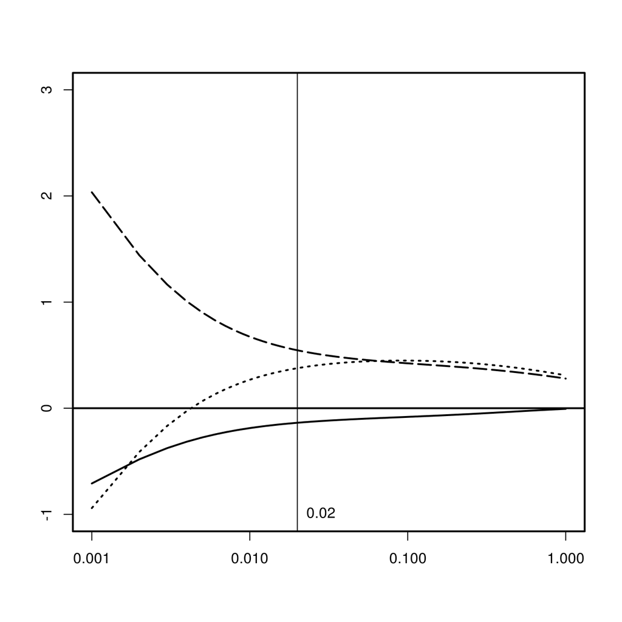

```r
lambda <- seq(0.001, 1, by = 0.001)
f <- function(c, x) {solve(cor(x)[-4, -4] + c * diag(3), cor(x)[-4, 4])}
tab <- data.frame(c = lambda,
                  t(sapply(lambda, f, x = .data)))

par(lwd = 2)
plot(x1 ~ c, tab, type = "l", log = "x", xaxt = "n", lty = 5,
     xlim = c(0.001, 1), ylim = c(-1, 3), xlab = "", ylab = "")
axis(1, c(0.001, 0.01, .10, 1.00))
lines(x2 ~ c, tab, lty = 3)
lines(x3 ~ c, tab, lty = 1)
abline(0,0)
abline(v = 0.02, lwd = 1)  # Authors choice of c
text(0.02, -1, pos=4, labels = "0.02")
```

## Input the Mathematics Proficiency Data

```r
.data <- CH11TA04
names(.data) <- c("State", "Y", "X1", "X2", "X3", "X4", "X5")
```

## FIGURE 11.5 (p 442)

#### Comparison of Lowess, Ordinary Least Squares Fits, and Robust Quadratic Fits–Mathematics Proficiency Example.

The author confuses the variables of interest. They begin by regressing on X2 (HOMELIB), but he talks about X3 (READING). I will maintain using X2 as the variable of interest.

Note that there is an R robust regression function `rlm` (*MASS*). It uses both the huber (`psi = psi.huber`) and bisquare (`psi.bisquare`) weighing functions. The latter method requires library *lqs*. For more see

> http://cran.r-project.org/doc/contrib/Fox-Companion/appendix-robust-regression.pdf

You can also use `hccm` (*car*) which gives you the ability to extract the adjusted VCV for your coefficients directly using a number of methods, (e.g., Huber-Weight HCO or Efron HC3). You would do something like

> `robust <- sqrt(diag(hccm(fit, type = "hc3"))) # Robust Standard Errors`coef(fit) / robust’ # Robust SE based t-test

Examples of this can be seen around the first hour in Dr. Justin Esarey’s online lecture at http://www.youtube.com/watch?v=kBlUStQcnJU

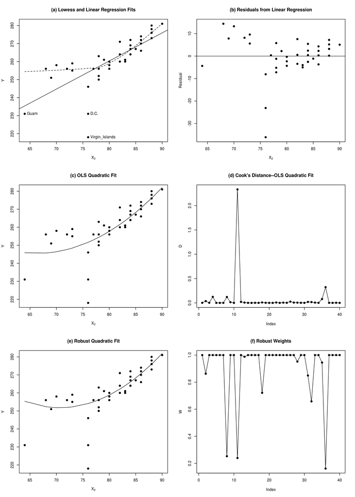

```r
library(MASS)
par(mfrow = c(3, 2), pch = 19)
xlab <- expression(X[2])

# Linear Regression Fit
fit  <- lm(Y ~ X2, .data)
outliers <- subset(.data, State %in% c("Guam", "D.C.", "Virgin_Islands"))

plot(Y ~ X2, .data, xlab = xlab, ylab = "Y")                          # (a)
lines(loess.smooth(.data$X2, .data$Y), lty = 2)
title("(a) Lowess and Linear Regression Fits")
abline(fit)
with(outliers, text(Y ~ X2, labels = State, pos = 4))

plot(resid(fit) ~ X2, .data, xlab = xlab, ylab = "Residual")          # (b)
title("(b) Residuals from Linear Regression")
abline(0, 0)

# OLS Quadratic Fit
fit <- lm(Y ~ x + xsq, transform(.data,
  x   = scale(X2, T, F),
  xsq = scale(X2, T, F)^2))
x <- data.frame(X2 = .data$X2, Y = fitted(fit))

plot(Y ~ X2, .data, xlab = expression(X[2]), ylab = "Y")              # (c)
title("(c) OLS Quadratic Fit")
lines(Y ~ X2, x[order(x$X2), ])

plot(cooks.distance(fit), xlab = "Index", ylab = "D", type = "o")  # (d)
title("(d) Cook's Distance--OLS Quadratic Fit")

# Robust Quadratic Fit
fit <- rlm(formula(fit), model.frame(fit))
x <- data.frame(X2 = .data$X2, Y = fitted(fit))

plot(Y ~ X2, .data, xlab = expression(X[2]), ylab = "Y")              # (e)
title("(e) Robust Quadratic Fit")
lines(Y ~ X2, x[order(x$X2), ])

plot(fit$w, xlab = "Index", ylab = "W", type = "o")                # (f)
title("(f) Robust Weights")
```

## TABLE 11.4 (p 443)

#### Data Set–Mathematics Proficiency Example.

```r
with(.data, cbind("State"    = State,
               "MATHPROF" = Y,
               "PARENTS"  = X1,
               "HOMELIB"  = X2,
               "READING"  = X3,
               "TVWATCH"  = X4,
               "ABSENCES" = X5))
```

```
##       State MATHPROF PARENTS HOMELIB READING TVWATCH ABSENCES
##  [1,]     1      252      75      78      34      18       18
##  [2,]     2      259      75      73      41      12       26
##  [3,]     3      256      77      77      28      20       23
##  [4,]     4      256      78      68      42      11       28
##  [5,]     5      267      78      85      38       9       25
##  [6,]     6      270      79      86      43      12       22
##  [7,]     8      261      75      83      32      18       28
##  [8,]     7      231      47      76      24      33       37
##  [9,]     9      255      75      73      31      19       27
## [10,]    10      258      73      80      36      17       22
## [11,]    11      231      81      64      32      20       28
## [12,]    12      251      78      69      36      23       26
## [13,]    13      272      84      84      48       7       21
## [14,]    14      260      78      82      43      14       21
```

[output cut: 26 more lines]

## TABLE 11.5 (p 444)

#### Iteratively Huber-Reweighted Least Squares Calculations–Mathematics Proficiency Example.

```r
fit <- lm(Y ~ x + xsq, transform(.data,
                                 x   = scale(X2, T, F),
                                 xsq = scale(X2, T, F)^2))

IRLS <- function(model, i = 1)
{
  e   <- resid(model)
  MAD <- median(abs(e - median(e))) / 0.6745  # (11.46)
  u   <- e / MAD  # (11.47)
  w   <- apply(data.frame(u), 1, function(x) if (abs(x) <= 1.345) 1 else 1.345/abs(x))  # (11.44)

  model <- update(model, weights = w)
  if (i > 1) return(IRLS(model, i-1)) else return(model)  # Recursive return definition
}

tab <- cbind(
  "e0" = resid(fit),
  "u0" = resid(fit) / (median(abs(resid(fit) - median(resid(fit)))) / 0.6745),
  "w1" = IRLS(fit, 1)$weights,
  "e1" = resid( IRLS(fit, 1) ),
  "w2" = IRLS(fit, 2)$weights,
  "e2" = resid( IRLS(fit, 2) ),
  "w7" = IRLS(fit, 7)$weights,
  "e7" = resid( IRLS(fit, 7) ))

round(tab, 4)
```

```
##          e0      u0     w1       e1     w2       e2     w7       e7
## 1   -2.4109 -0.5164 1.0000  -3.7542 1.0000  -4.0354 1.0000  -4.1269
## 2   10.5724  2.2647 0.5939   8.4297 0.7151   7.4848 0.8601   6.7698
## 3    3.0454  0.6523 1.0000   1.5411 1.0000   1.1559 1.0000   0.9731
## 4   10.3104  2.2085 0.6090   7.3822 0.8166   5.4138 1.0000   3.6583
## 5   -1.2395 -0.2655 1.0000  -1.4402 1.0000  -1.3970 1.0000  -1.3160
## 6   -0.7342 -0.1573 1.0000  -0.7695 1.0000  -0.7376 1.0000  -0.6986
## 7   -2.6394 -0.5654 1.0000  -3.1694 1.0000  -3.1469 1.0000  -3.0318
## 8  -20.6282 -4.4187 0.3044 -22.2929 0.2704 -22.7964 0.2526 -23.0873
## 9    6.5724  1.4078 0.9554   4.4297 1.0000   3.4848 1.0000   2.7698
## 10   0.2871  0.0615 1.0000  -0.7325 1.0000  -0.8490 1.0000  -0.8079
## 11 -14.8358 -3.1779 0.4232 -18.3824 0.3279 -21.4287 0.2402 -24.3167
## 12   5.0224  1.0758 1.0000   2.2502 1.0000   0.5153 1.0000  -0.9988
## 13   6.1255  1.3121 1.0000   5.7598 1.0000   5.7999 0.9875   5.9063
## 14  -1.5341 -0.3286 1.0000  -2.2278 1.0000  -2.2373 1.0000  -2.1301
```

[output cut: 26 more lines]

## FIGURE 11.6 (p 446)

#### Scatter Plot Matrix with Lowess Smooths, and Correlation Matrix–Mathematics Proficiency Example.

The use of `pairs` could produce these results, but I want to demonstrate the facility of the `scatterplotMatrix` function (*car*). It has an `spm` use for convenience. Also, the author’s plot isn’t right for *TVWATCH*. If you plot the scatterplot of it against any of the other variables, you do not get the results in this scatterplot matrix. The rest of the scatterplots look fine, and so does the correlation table.

```r
library(car)
cor(.data[-1])
```

```
##          Y      X1      X2      X3      X4      X5
## Y   1.0000  0.7414  0.7451  0.7166 -0.8735 -0.4803
## X1  0.7414  1.0000  0.3945  0.6930 -0.8312 -0.5653
## X2  0.7451  0.3945  1.0000  0.3769 -0.5936 -0.4426
## X3  0.7166  0.6930  0.3769  1.0000 -0.7919 -0.3567
## X4 -0.8735 -0.8312 -0.5936 -0.7919  1.0000  0.5117
## X5 -0.4803 -0.5653 -0.4426 -0.3567  0.5117  1.0000
```

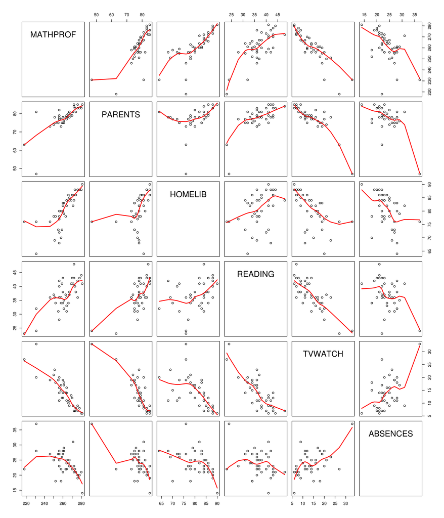

```r
spm(.data[-1], span = 0.75, diagonal = "none", reg.line = FALSE, spread = FALSE,
  var.labels = c("MATHPROF", "PARENTS", "HOMELIB",
                 "READING", "TVWATCH", "ABSENCES"))
```

## TABLE 11.6 (p 447)

#### Diagnostics for First-Order Model with All Five Explanatory Variables–Mathematics Proficiency Example.

```r
fit <- lm(Y ~ X1 + X2 + X3 + X4 + X5, .data)
data.frame("State" = levels(.data$State),
           "h"     = round(hatvalues(fit), 2),
           "t"     = round(rstudent(fit), 2),
           "D"     = round(cooks.distance(fit), 2))
```

[output not shown]

[output cut: 26 more lines]

## UNPRESENTED FIGURE (p 447)

#### Residual plots against each independent variable and dependent variable–Mathematics Proficiency Example.

The author indicates that the residual plots present no strong indication of nonconstancy of the error variance for the states aside from the outliers.

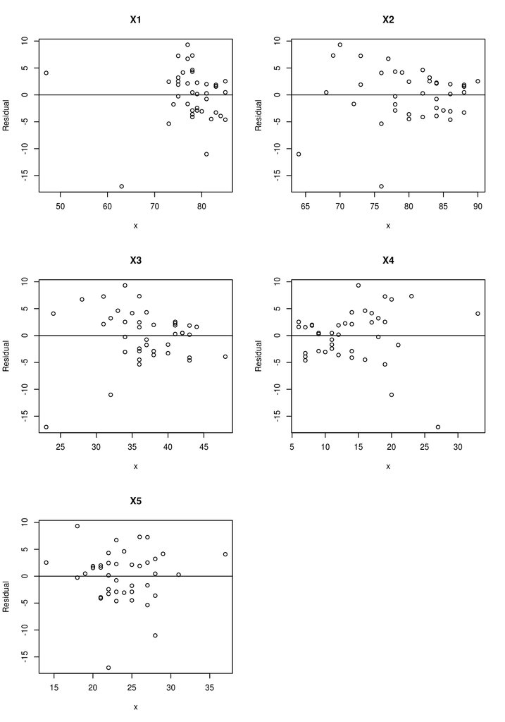

```r
par(mfrow = c(3, 2))
for (n in seq(5))
{
    x <- model.frame(fit)[, n+1]
    predictor <- paste("X", n, sep = "")
    plot(resid(fit) ~ x, ylab = "Residual", main = predictor)
    abline(0, 0)
}
```

## FIGURE 11.7 (p 448)

#### Best Subsets Regression–Mathematics Proficiency Example.

In the earlier chapter I used `regsubsets` (*leaps*) to produce the possible submodels and their selection criteria, displaying the best based on the number of the “best” parameter. Another approach is to use `bestglm` (*bestglm*). The `regsubsets` will produce an output similar to that found in `FIGURE 11.7`, but `bestglm` offers some of its own flexibility. See more at the document:

> http://cran.r-project.org/web/packages/bestglm/vignettes/bestglm.pdf

```r
library(bestglm)
bestglm(model.frame(fit)[c(2:6, 1)], IC = "AIC")$Subsets  # Author's choice is 3 on each search
```

```
##    (Intercept)    X1    X2    X3    X4    X5 logLikelihood   AIC
## 0         TRUE FALSE FALSE FALSE FALSE FALSE       -102.69 205.4
## 1         TRUE FALSE FALSE FALSE  TRUE FALSE        -73.90 149.8
## 2         TRUE FALSE  TRUE FALSE  TRUE FALSE        -65.76 135.5
## 3         TRUE FALSE  TRUE  TRUE  TRUE FALSE        -64.55 135.1
## 4*        TRUE  TRUE  TRUE  TRUE  TRUE FALSE        -63.53 135.1
## 5         TRUE  TRUE  TRUE  TRUE  TRUE  TRUE        -63.22 136.4
```

```r
bestglm(model.frame(fit)[c(2:6, 1)], IC = "BIC")$Subsets
```

```
##    (Intercept)    X1    X2    X3    X4    X5 logLikelihood   BIC
## 0         TRUE FALSE FALSE FALSE FALSE FALSE       -102.69 205.4
## 1         TRUE FALSE FALSE FALSE  TRUE FALSE        -73.90 151.5
## 2*        TRUE FALSE  TRUE FALSE  TRUE FALSE        -65.76 138.9
## 3         TRUE FALSE  TRUE  TRUE  TRUE FALSE        -64.55 140.2
## 4         TRUE  TRUE  TRUE  TRUE  TRUE FALSE        -63.53 141.8
## 5         TRUE  TRUE  TRUE  TRUE  TRUE  TRUE        -63.22 144.9
```

```r
summary(rlm(Y ~ X2 + X3 + X4, .data))  # (11.53)
```

```
##
## Call: rlm(formula = Y ~ X2 + X3 + X4, data = .data)
## Residuals:
##    Min     1Q Median     3Q    Max
## -22.40  -3.00   0.56   2.68   9.41
##
## Coefficients:
##             Value   Std. Error t value
## (Intercept) 207.681  17.696     11.736
## X2            0.797   0.140      5.698
## X3            0.161   0.221      0.728
## X4           -1.169   0.223     -5.241
##
## Residual standard error: 4.34 on 36 degrees of freedom
```

```r
summary(lm (Y ~ X2 + X3 + X4, .data))  # (11.54)
```

```
##
## Call:
## lm(formula = Y ~ X2 + X3 + X4, data = .data)
##
## Residuals:
##     Min      1Q  Median      3Q     Max
## -18.926  -2.948   0.256   2.461   9.696
##
## Coefficients:
##             Estimate Std. Error t value Pr(>|t|)
## (Intercept)  199.611     21.529    9.27  4.5e-11 ***
## X2             0.780      0.170    4.59  5.3e-05 ***
## X3             0.401      0.269    1.49  0.14423
## X4            -1.156      0.271   -4.26  0.00014 ***
## ---
## Signif. codes:  0 '***' 0.001 '**' 0.01 '*' 0.05 '.' 0.1 ' ' 1
##
## Residual standard error: 5.29 on 36 degrees of freedom
## Multiple R-squared:  0.851,  Adjusted R-squared:  0.839
## F-statistic: 68.8 on 3 and 36 DF,  p-value: 5.65e-15
```

```r
with(summary(regsubsets(formula(fit), .data, nbest=2)),
     cbind(which[, -1], rss, rsq, adjr2, cp, bic))
```

```
##   X1 X2 X3 X4 X5    rss    rsq  adjr2     cp    bic
## 1  0  0  0  1  0 1609.4 0.7630 0.7567 21.993 -50.20
## 1  0  1  0  0  0 3020.6 0.5551 0.5434 72.842 -25.02
## 2  0  1  0  1  0 1071.3 0.8422 0.8337  4.604 -62.79
## 2  1  1  0  0  0 1410.5 0.7923 0.7810 16.826 -51.79
## 3  0  1  1  1  0 1008.9 0.8514 0.8390  4.354 -61.51
## 3  1  1  0  1  0 1013.6 0.8507 0.8383  4.524 -61.32
## 4  1  1  1  1  0  958.3 0.8589 0.8427  4.532 -59.88
## 4  1  1  0  1  1  993.7 0.8536 0.8369  5.808 -58.42
## 5  1  1  1  1  1  943.6 0.8610 0.8406  6.000 -56.81
```

## Input Life Insurance Data

```r
.data <- CH11TA07
names(.data) <- c("X1", "X2", "Y")
```

## TABLE 11.7 (p 451)

#### Lowess Calculations for Non-parametric Regression Fit at Xh1 = 30, Xh2 = 3–Life Insurance Example.

```r
fit <- lm(Y ~ X1 + X2, .data)  # (6.1)
lo <- function(model, newdata = data.frame(X1 = 30, X2 = 3), q = 0.5)
{
  x<- transform(model.frame(model),
    d = sqrt(scale(X1, newdata$X1, sd(X1))^2 + scale(X2, newdata$X2, sd(X2))^2))
  dq <- with(x, sort(d)[nrow(x) * q])
  x <- transform(x, w = ifelse(d > dq, 0, (1-(d/dq)^3)^3))
  with(x, update(model, weights = w))
}

transform(.data,
  d = sqrt(scale(X1, 30, sd(X1))^2 + scale(X2, 3, sd(X2))^2),
  w = lo(fit)$weights)
```

```
##       X1 X2   Y       d       w
## 1  66.29  7 240 3.01254 0.00000
## 2  40.96  5  73 1.14306 0.29974
## 3  73.00 10 311 4.21154 0.00000
## 4  45.01  6 136 1.65285 0.00000
## 5  57.20  4 183 1.89606 0.00000
## 6  26.85  5  13 0.89378 0.59668
## 7  38.12  4  35 0.70141 0.78781
## 8  35.84  6  61 1.36080 0.08631
## 9  65.80  9 319 3.56056 0.00000
## 10 37.41  5  30 1.00292 0.46835
## 11 54.38  2 148 1.70985 0.00000
## 12 46.19  7 116 2.05401 0.00000
## 13 46.13  4  71 1.17728 0.26047
## 14 30.37  3  10 0.02483 0.99999
## 15 39.06  5  89 1.06353 0.39479
## 16 79.38  1 316 3.46092 0.00000
## 17 52.77  8 154 2.66338 0.00000
## 18 55.92  6 164 2.18782 0.00000
```

```r
predict(lo(fit), data.frame(X1 = 30, X2 = 3))  # 4.664607
```

```
##     1
## 4.665
```

```r
# Compare
fit <- loess(Y ~ X1 + X2, .data, span = 0.5, degree = 1)
predict(fit, data.frame(X1 = 30, X2 = 3))  # returns 4.2894 with normalize = FALSE
```

```
##     1
## 9.824
```

## FIGURE 11.8 (p 452)

#### Contour and Conditioning Plots for Lowess Nonparametric Regression–Life Insurance Example.

Loess regressions can have a variety of results due to small calibrations in the possible parameters. While I cannot fit a model to exactly produce what the book expects, I demonstrate how to do contour plots, extend that to a 3D surface, and do the associated coplots manually. There does exist a `coplot` function, but you will have to figure it out.

The `contour` function operates as a 2D analog to `persp`. Therefore, the same approach used in the `lm3d` function defined in chapter 6 for `FIGURE 6.7` can be used here. Simply feed it the 3 dimensional sequences as below. To that end, `lm3d` has been modified to invisibly return those 3 sequences (as a list) and are then passed to `contour`.

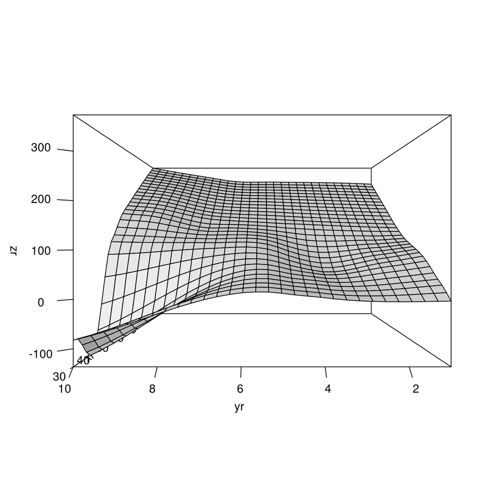

```r
lm3d <- function(model, res, ...) {
  ivs <- labels(terms(model))
  x <- model.frame(model)[, ivs[1]]     # 1st independent variable
  y <- model.frame(model)[, ivs[2]]     # 2nd independent variable
  xr <- seq(min(x), max(x), len = res)  # equidistant sequence from range of 1st iv
  yr <- seq(min(y), max(y), len = res)  # equidistant sequence from range of 2nd iv

  # Create a list object of these sequences to be turned into a grid
  newdata <- list(xr, yr)
  names(newdata) <- ivs
  newdata <- do.call('expand.grid', newdata)

  zr <- matrix(predict(model, newdata), res, res)
  persp(xr, yr, zr, ...)

  invisible(list(x = xr, y = yr, z = zr))  # included in this example for `contour`
}

fit <- loess(Y ~ X1 + X2, .data, span = 0.5, degree = 1)
lm3d(fit, res = 30, theta = 270, phi = 0, ticktype = "detailed", expand = 2/3, shade = 0.5)
```

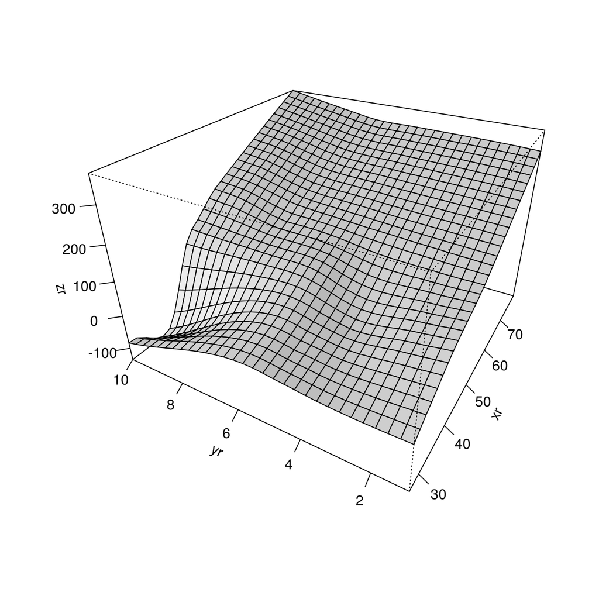

```r
# Store the dimensional sequences for the plots below
.data <- lm3d(fit, res = 30, theta = 300, phi = 30, ticktype = "detailed", expand = 2/3, shade = 0.5)
```

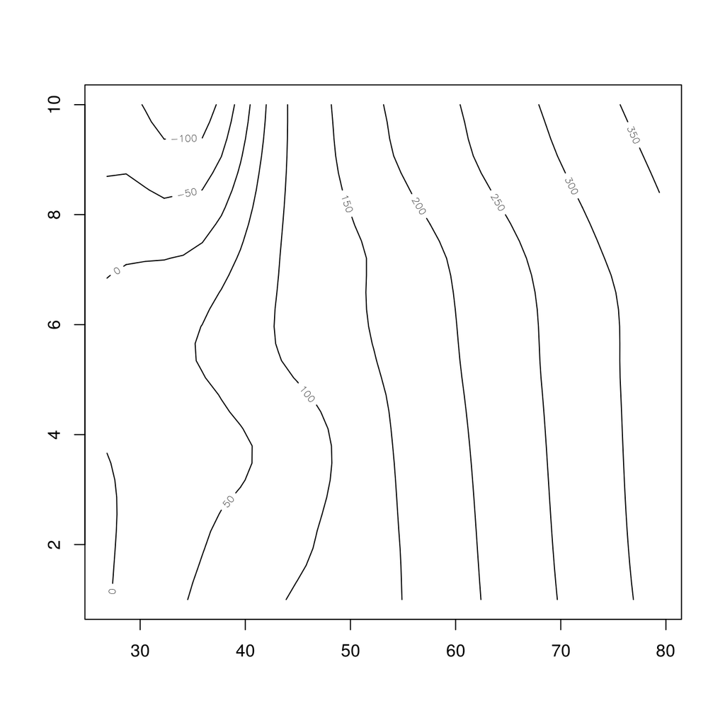

```r
with(.data, contour(x, y, z))
```

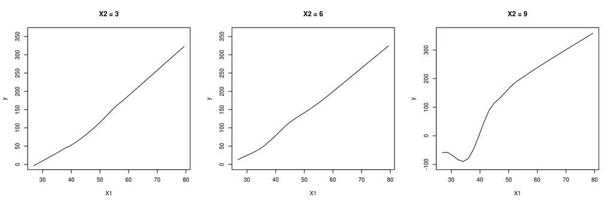

```r
par(mfrow = c(1, 3))
plot(.data$x, predict(fit, data.frame(X1=.data$x, X2=3)), type='l', ylim=c(0, 360), ylab = 'y', xlab = 'X1')
title("X2 = 3")

plot(.data$x, predict(fit, data.frame(X1=.data$x, X2=6)), type='l', ylim=c(0, 360), ylab = 'y', xlab = 'X1')
title("X2 = 6")

# Very different scale than book
plot(.data$x, predict(fit, data.frame(X1=.data$x, X2=9)), type='l', ylim=c(-100, 360), ylab = 'y', xlab = 'X1')
title("X2 = 9")
```

## Input Steroid Level Data

```r
.data <- CH11TA08
names(.data) <-c("Y", "X")
```

## TABLE 11.8 (p 453)

#### Data Set and 5-Region Regression Tree Fit–Steriod Level Example.

The `cut` function will easily factor Age into the regions (R) of interest. However, since these are left-closed, right-opened, the appropriate parameters are specified. The book says to not include `Age = 25` (it’s right open). This doesn’t seem right, and `cut` doesn’t allow it. The mean score is not too different.

```r
.data <- transform(.data,
                R = cut(X, c(8, 9, 10, 13, 14, 25), include.lowest = TRUE, right = FALSE))
with(.data, tapply(Y, R, mean))
```

```
##   [8,9)  [9,10) [10,13) [13,14) [14,25]
##   3.550   8.133  13.675  16.950  22.269
```

## FIGURE 11.9 (p 454)

#### Fitted Regression Tree, Residual Plot, and Regression Tree Diagram–Steroid Level Example.

While the above method demonstrates an approach to categorizing our bins in a regression tree, the authors have not demonstrated much in the way of how to construct the trees. Therefore, I will simply use R facilities to generate the authors output as close as possible. For more on the topic of data mining and regression tress I suggest the author’s recommendation (11.15), Hastie et al. *The Elements of Statistical Learning*.

R has a regression tree function `rpart` (*rpart*). It takes in a regression formula or object and generates a tree. To manage the parameters of the tree, you manipulate the control parameter using the rpart function `rpart.control`. The selection of parameters in this case were trial-and-error. Since there were at least two Y values in each bin, I set the `minsplit = 2`. The cp value defaults to `0.01`, which results in breaking up the `[14, 25]` bin. It turns out that `cp = 0.013` maintained the author’s results. The return object of *rpart* can be used just like an lm object as demonstrated below.

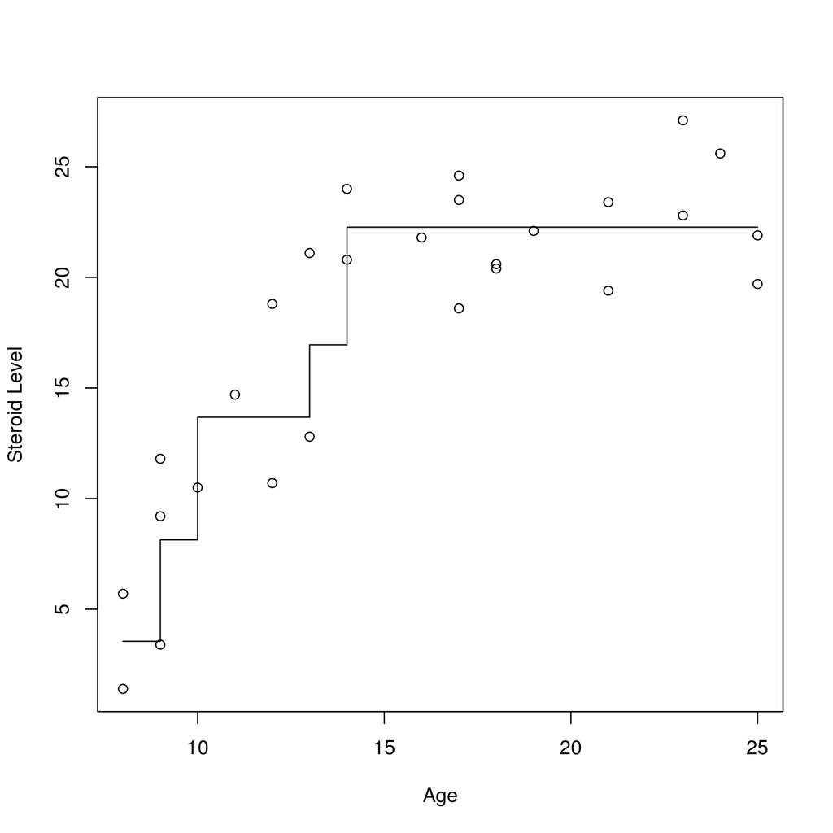

```r
library(rpart)

fit <- rpart(Y ~ X, .data, control = rpart.control(minsplit = 2, cp = 0.013))

# FIGURE 11.9a
plot(Y ~ X, .data, xlab = "Age", ylab = "Steroid Level")
lines(predict(fit, data.frame(X = sort(X))) ~ sort(X), .data, type = 's')  # Step plot
```

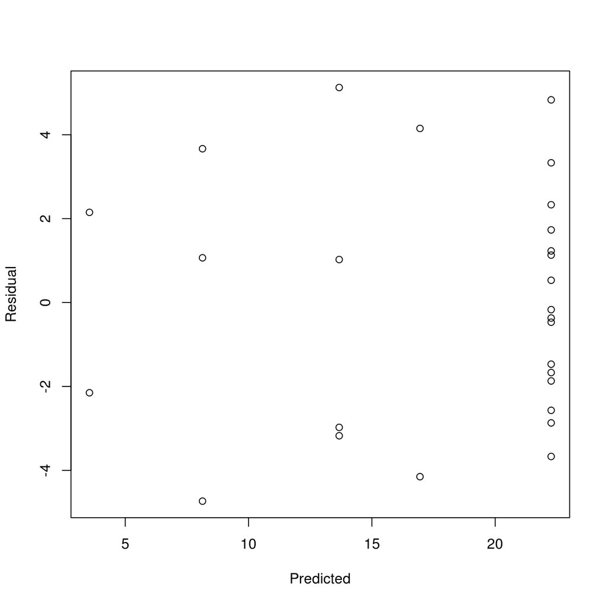

```r
# FIGURE 11.9b
plot(resid(fit) ~ predict(fit), xlab = "Predicted", ylab = "Residual")
```

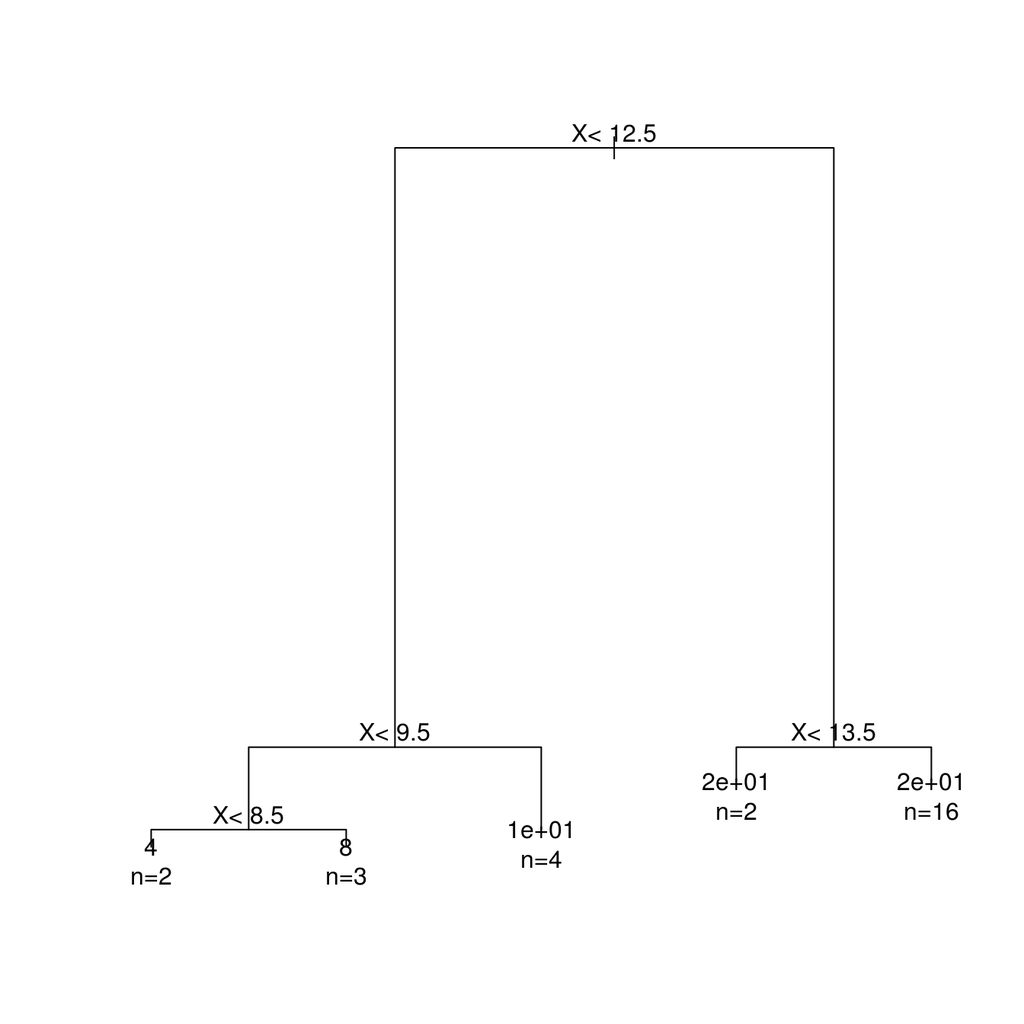

```r
# FIGURE 11.9c
plot(fit)
text(fit, use.n = TRUE, xpd = TRUE)
```

#### Growing the Regression Tree–Steroid Level Example

To grow the tree is basically to manipulate the parameters in `rpart`. Therefore, I will construct a few different models and plot them like the above step function. To faciliate that, I will write a convenience wrapper that plots the results. All parameters go straight to `rpart`.

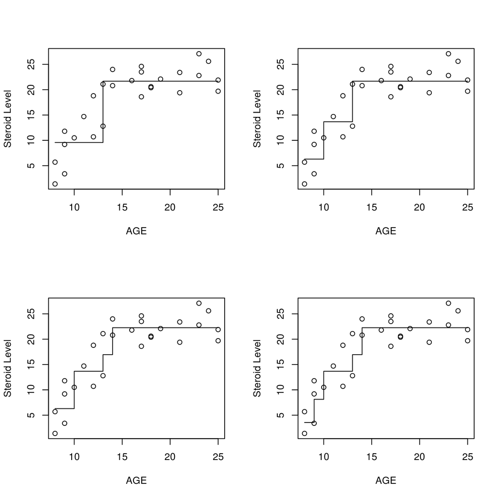

```r
rplot <- function(formula, data, ...)
{
  .data <- model.frame(formula, data)
  model <- rpart(Y ~ X, .data, ...)
  plot(formula, .data, xlab = "AGE", ylab = "Steroid Level")
  lines(predict(model, data.frame(X = sort(X))) ~ sort(X), .data, type = 's')
}

par(mfrow = c(2, 2))
rplot(Y ~ X, .data, minsplit = 2, cp = 0.095)
rplot(Y ~ X, .data, minsplit = 2, cp = 0.04)
rplot(Y ~ X, .data, minsplit = 2, cp = 0.03)
rplot(Y ~ X, .data, minsplit = 2, cp = 0.015)
```

## Import University Admissions data (Appendix C.4)

```r
.data <- APPENC04
names(.data) <- c("id", "gpa", "rank", "score", "year")
```

## FIGURE 11.12 (p 457)

#### Regression Tree Results–University Admissions Example

The `lm3d` function is generic enough to even handle regression tree models. The only requirement is that the `rpart` parameter `model = TRUE` be set so that `model.frame` will actually return the data frame that comprises this model.

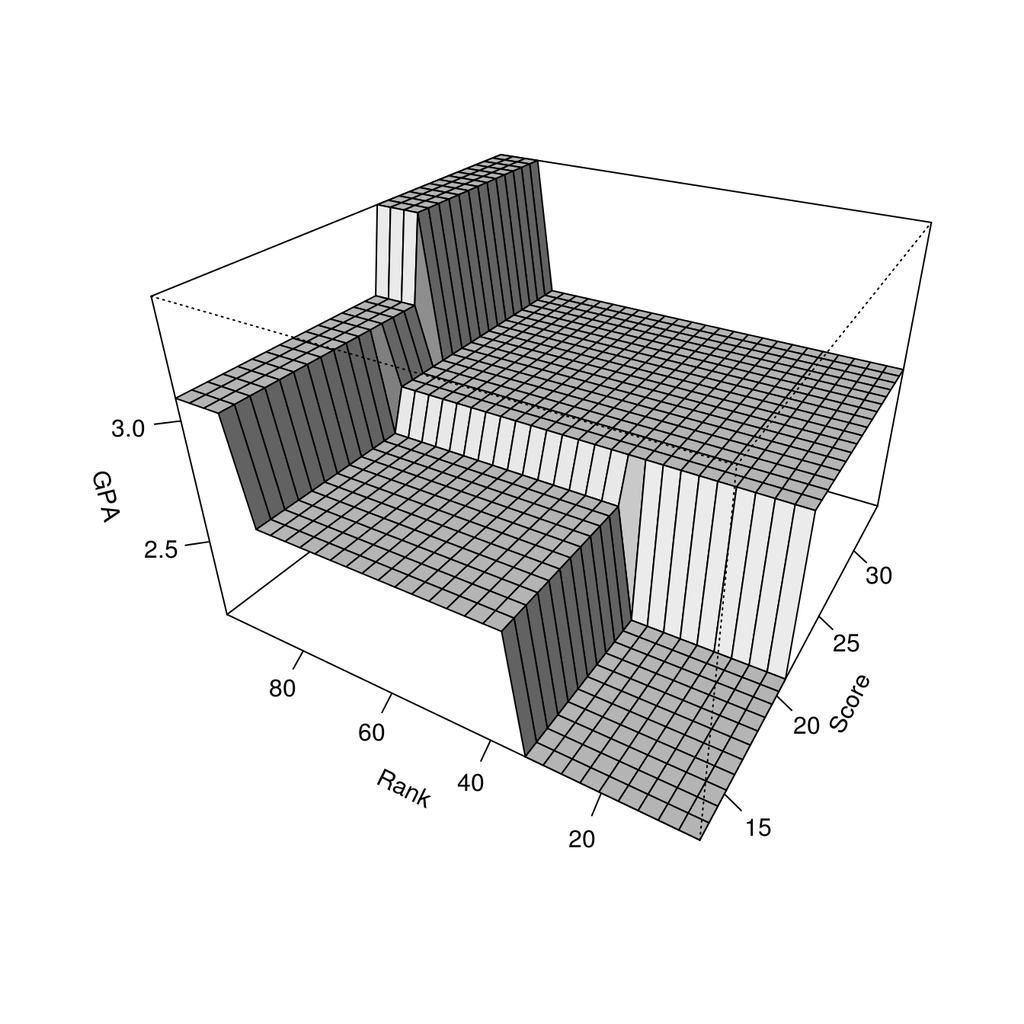

```r
library(rpart)
set.seed(38383)  # I want more control over what model gets generated here.
indices <- sample(nrow(.data), 400)
.data.test <- .data[indices, ]
.data.valid <- .data[-indices, ]
fit <- rpart(gpa ~ score + rank, .data.test, cp = 0.015, model = TRUE)

mspr <- function(model, validation)
{
  x <- model.frame(formula(model), validation)
  x <- sum((x[, 1] - predict(model, x[-1]))^2) / nrow(x)  # (9.20)

  return(x)
}

x <- NULL
for (cp in seq(0.01, 0.04, by = 0.001))
  x <- append(x, mspr(rpart(gpa ~ rank + score, .data.test, cp = cp), .data.valid))

x <- NULL
for (n in seq(30)) {
  for (cp in seq(0.01, 0.03, by = 0.001)) {
    x <- append(x, mspr(rpart(gpa ~ rank + score, .data.test, maxdepth = n, cp = cp), .data.valid))
  }
}
x <- data.frame(depth = rep(seq(30), each = 21), cp = seq(0.01, 0.03, by = 0.001), mspr = x)

# FIGURE 11.12 (a)



# FIGURE 11.12 (b)
lm3d(fit, 30, theta = 300, phi = 30, ticktype = "detailed", expand = 2/3, shade = 0.5, xlab = "Score", ylab = "Rank", zlab = "GPA")
```

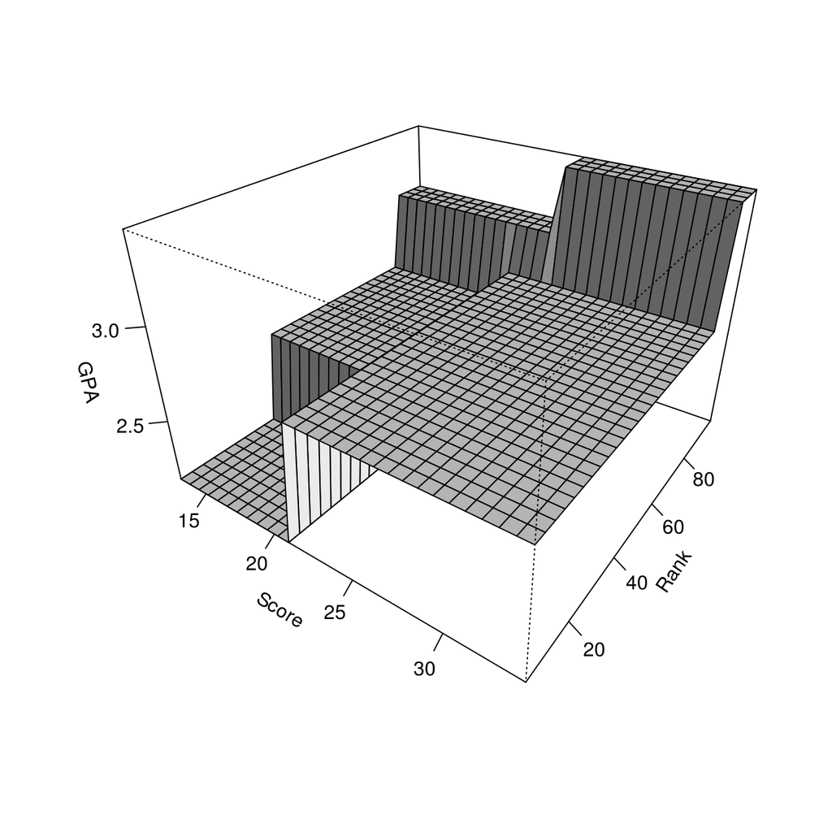

```r
lm3d(fit, 30, theta = 35, phi = 30, ticktype = "detailed", expand = 2/3, shade = 0.5, xlab = "Score", ylab = "Rank", zlab = "GPA")
```

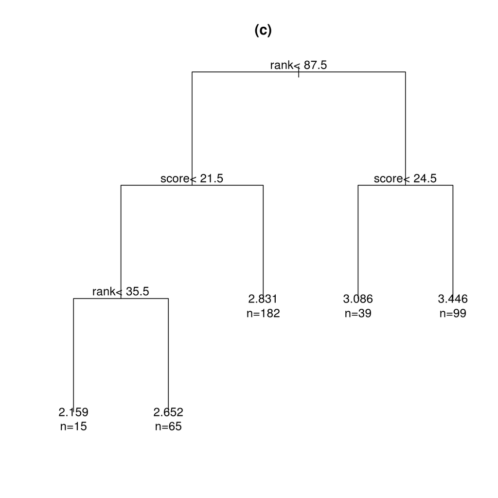

```r
# FIGURE 11.12 (c)
plot(fit, compress = TRUE, uniform = TRUE)
text(fit, use.n = TRUE, xpd = TRUE, digits = 4)
title("(c)")
```

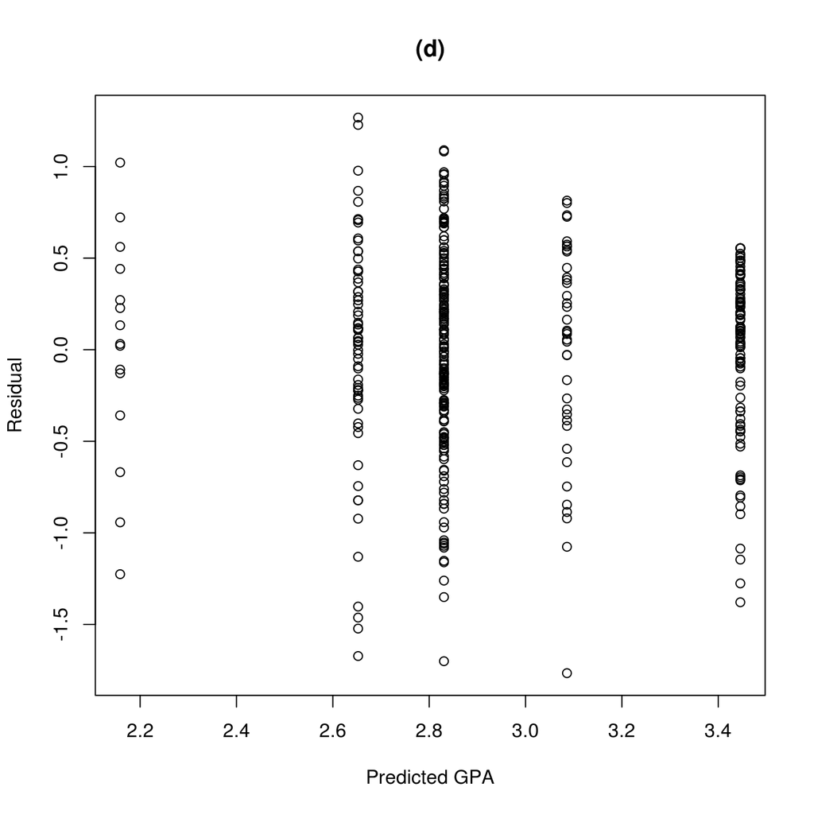

```r
# FIGURE 11.12 (d)
plot(predict(fit), resid(fit), xlab = "Predicted GPA", ylab = "Residual")
title("(d)")
```

## Input the Toluca Company Data

```r
.data <- CH11TA09
names(.data) <- c("X", "Y")
fit <- lm(Y ~ X, .data)
```

## TABLE 11.9 (p 461)

#### Bootstrapping with Fixed X Sampling–Toluca Company Example

Columns (5) and (6) will be different since (5) is selected by a random sample from the residuals of the original model. The given trial will not be part of the following 1000 bootstraps. This is here for completeness.

```r
estar <- sample(resid(fit), size = nrow(.data), replace = TRUE)
cbind(.data,
      'Yh'    = fitted(fit),
      'ei'    = resid(fit),
      'estar' = estar,
      'ystar' = fitted(fit) + estar)
```

```
##      X   Y    Yh       ei    estar ystar
## 1   80 399 348.0  51.0180  38.8261 386.8
## 2   30 121 169.5 -48.4719   5.3160 174.8
## 3   50 221 240.9 -19.8760 -48.4719 192.4
## 4   90 376 383.7  -7.6840 -66.3861 317.3
## 5   70 361 312.3  48.7200 -52.5780 259.7
## 6   60 224 276.6 -52.5780  51.0180 327.6
## 7  120 546 490.8  55.2099  42.5281 533.3
## 8   80 352 348.0   4.0180  51.0180 399.0
## 9  100 353 419.4 -66.3861 -20.0881 399.3
## 10  50 157 240.9 -83.8760  -7.6840 233.2
## 11  40 160 205.2 -45.1739   0.6139 205.8
## 12  70 252 312.3 -60.2800 -66.3861 245.9
## 13  90 389 383.7   5.3160  10.7200 394.4
## 14  20 113 133.8 -20.7699 -20.0881 113.7
## 15 110 435 455.1 -20.0881 -20.0881 435.0
## 16 100 420 419.4   0.6139 -52.5780 366.8
## 17  30 212 169.5  42.5281 -48.4719 121.0
## 18  50 268 240.9  27.1240   0.6139 241.5
## 19  90 377 383.7  -6.6840   4.0180 387.7
## 20 110 421 455.1 -34.0881  42.5281 497.6
## 21  30 273 169.5 103.5281 -60.2800 109.2
## 22  90 468 383.7  84.3160 -45.1739 338.5
## 23  40 244 205.2  38.8261 -20.7699 184.4
## 24  80 342 348.0  -5.9820  51.0180 399.0
## 25  70 323 312.3  10.7200   4.0180 316.3
```

## FIGURE 11.13 (p 461)

#### Histogram of Bootstrap Estimates b1*–Toluca Company Example

```r
bootstrap <- function(model, times = 1000, alpha = 0.05)
{
  b     <- coef(model)[[2]]
  n     <- nrow(model.frame(model))
  coefs <- vector(mode = "numeric", length = times)
  for (i in seq(times))
  {
    estar <- sample(resid(model), size = n, replace = TRUE)
    fstar <- fitted(model) + estar
    bootmodel  <- lm(fstar ~ ., data = model.frame(model))
    coefs[i] <- coef(bootmodel)[[2]]
  }

  p <- quantile(coefs, probs = c(alpha/2, 1-alpha/2))

  statistics <- cbind(
    "mean"      = mean(coefs),
    "sd"        = sd(coefs),
    "b(a/2)"    = p[[1]],
    "b(1-a/2)"  = p[[2]])

  confint <- cbind(
    'd1'  = b - p[[1]],
    'd2'  = p[[2]] - b,
    'lwr' = 2*b - p[[2]],
    'upr' = 2*b - p[[1]])

  return (list(coefs = coefs, statistics = statistics, confint = confint))
}

z <- bootstrap(fit)
z$statistics
```

```
##           mean     sd  b(a/2) b(1-a/2)
## [1,] -0.001328 0.1993 -0.3981   0.3745
```

```r
z$confint
```

```
##         d1     d2   lwr   upr
## [1,] 3.968 -3.196 6.766 7.539
```

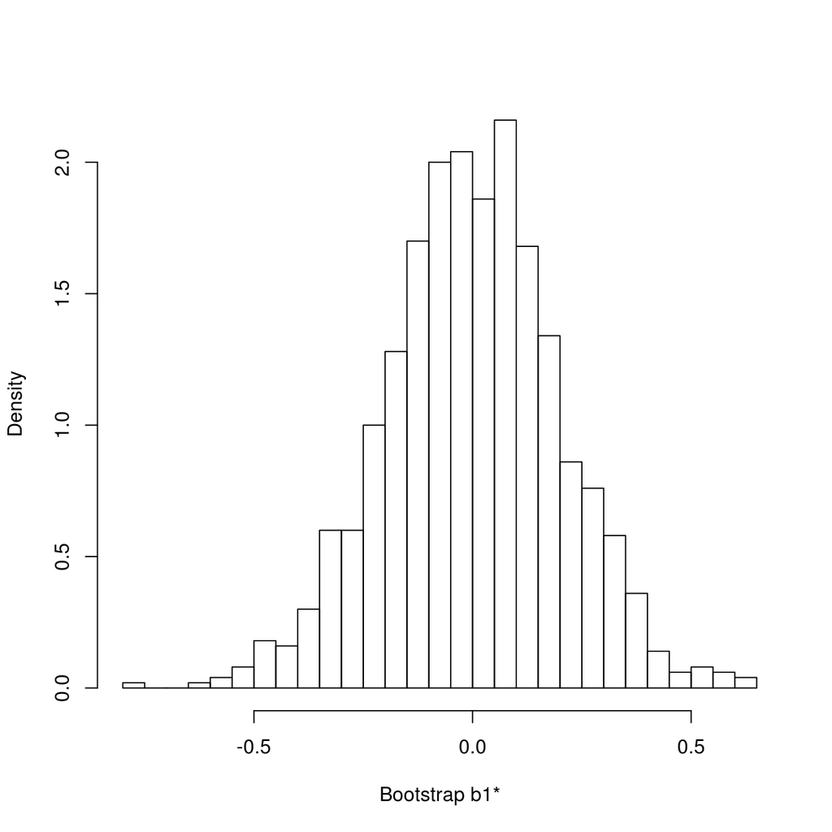

```r
hist(z$coefs, breaks = 40, freq = F, main = "", xlab = "Bootstrap b1*")
```

## Input Blood Pressure data

```r
.data <- CH11TA10
names(.data) <- c("X", "Y")
fit  <- lm(Y ~ X, .data)
```

## TABLE 11.10 (p 462)

#### Bootstrapping with Random X Sampling–Blood Pressure Example

```r
xstar <- sample(.data$X, size = nrow(.data), replace = TRUE)
ystar <- sample(.data$Y, size = nrow(.data), replace = TRUE)
estar <- abs(resid(lm(ystar ~ xstar) ))
cbind(.data,
  'X*' = xstar,
  'Y*' = ystar,
  'e*' = round( resid( lm(ystar ~ xstar) ), 2),
  's*' = round( fitted( lm(estar ~ xstar) ), 2),
  'w*' = round( 1 / (fitted( lm(estar ~ xstar) ))^2, 4))
```

```
##     X   Y X*  Y*     e*    s*     w*
## 1  27  73 33 101  21.38  8.58 0.0136
## 2  21  66 43  73  -3.82  7.44 0.0181
## 3  22  63 57  92  19.11  5.84 0.0293
## 4  24  75 49  71  -4.14  6.75 0.0219
## 5  25  71 57  66  -6.89  5.84 0.0293
## 6  23  70 48  90  14.58  6.87 0.0212
## 7  20  65 47  63 -12.70  6.98 0.0205
## 8  20  70 45  71  -5.26  7.21 0.0192
## 9  29  79 50  71  -3.86  6.64 0.0227
## 10 24  72 43  92  15.18  7.44 0.0181
## 11 25  68 30  72  -8.46  8.92 0.0126
## 12 28  67 24  83   0.86  9.60 0.0108
## 13 26  79 42  80   2.90  7.55 0.0175
## 14 38  91 56  73  -0.17  5.95 0.0282
```

[output cut: 40 more lines]

## FIGURE 11.14 (p 463)

#### Histogram of Boostrap Estimates b1*–Blood Pressure Example

I first code an algorithm similar to the one used in the previous example. I then finish by showing the R approach using `boot` (*boot*). To use `boot` requires you to define a statistic. In this case, we define a function `boot.coef` that extracts the coefficient of interest as in the other defined functions. The boot function then calculates the relevant information, and we can use the `boot.ci` function to generate confidence intervals using a number of methods.

```r
library(boot)
bootstrap <- function(model, times = 1000, alpha = 0.05)
{
  b     <- coef(model)[[2]]
  n     <- nrow(model.frame(model))
  coefs <- vector(mode = "numeric", length = times)
  for(i in seq(times))
  {
    indices  <- sample(1:n, size = n, replace = TRUE)
    xstar    <- model.frame(model)[indices, 2]
    ystar    <- model.frame(model)[indices, 1]
    mod      <- lm(ystar ~ xstar)
    mod      <- update(mod, weights = fitted(lm(abs(resid(mod)) ~ xstar))^(-2))
    coefs[i] <- coef(mod)[[2]]
  }

  p <- quantile(coefs, probs = c(alpha/2, 1-alpha/2))

  statistics <- cbind(
    "mean"     = mean(coefs),
    "sd"       = sd(coefs),
    "b(a/2)"   = p[[1]],
    "b(1-a/2)" = p[[2]])

  confint <- cbind(
    'd1'  = b - p[[1]],
    'd2'  = p[[2]] - b,
    'lwr' = 2*b - p[[2]],
    'upr' = 2*b - p[[1]])

  return (list(coefs = coefs, statistics = statistics, confint = confint))
}

boot.coef <- function(data, indices)
{
  x   <- data[indices, 2]
  y   <- data[indices, 1]
  mod <- lm(y ~ x)
  mod <- update(mod, weights = fitted(lm(abs(resid(mod)) ~ x))^(-2))
  coef(mod)[[2]]
}

z <- bootstrap(fit)
z$statistics
```

```
##        mean      sd b(a/2) b(1-a/2)
## [1,] 0.5963 0.08503 0.4294   0.7613
```

```r
z$confint
```

```
##          d1     d2    lwr    upr
## [1,] 0.1507 0.1813 0.3987 0.7307
```

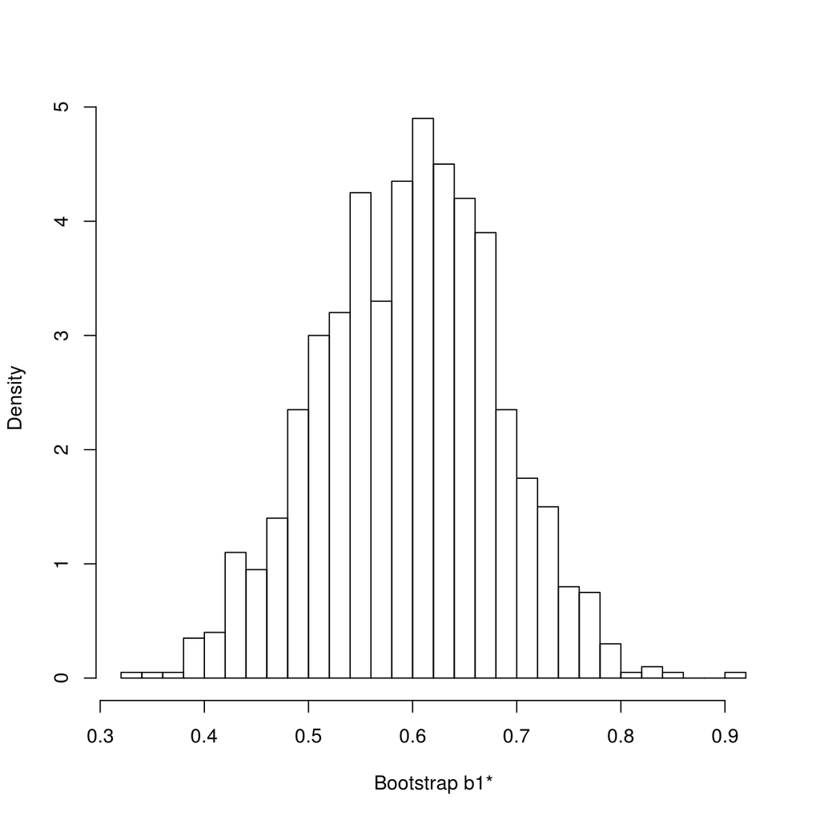

```r
hist(z$coefs, breaks = 40, freq = F, main = "", xlab = "Bootstrap b1*")
```

```r
# Using the boot package
z <- boot(data = model.frame(fit), statistic = boot.coef, R = 1000)
print(z)
```

```
##
## ORDINARY NONPARAMETRIC BOOTSTRAP
##
##
## Call:
## boot(data = model.frame(fit), statistic = boot.coef, R = 1000)
##
##
## Bootstrap Statistics :
##     original    bias    std. error
## t1*   0.5963 -0.001853     0.08567
```

```r
boot.ci(z)
```

```
## BOOTSTRAP CONFIDENCE INTERVAL CALCULATIONS
## Based on 1000 bootstrap replicates
##
## CALL :
## boot.ci(boot.out = z)
##
## Intervals :
## Level      Normal              Basic
## 95%   ( 0.4303,  0.7661 )   ( 0.4309,  0.7672 )
##
## Level     Percentile            BCa
## 95%   ( 0.4255,  0.7618 )   ( 0.4315,  0.7675 )
## Calculations and Intervals on Original Scale
```

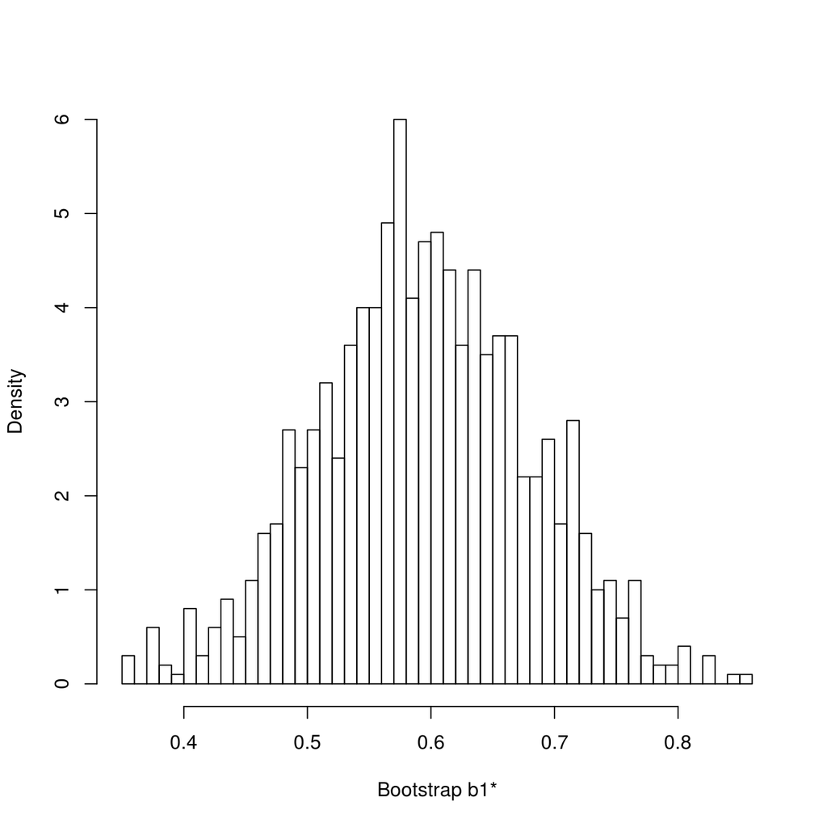

```r
hist(z$t, breaks = 40, freq = F, main = "", xlab = "Bootstrap b1*")
```

## Input Traffic Data

```r
.data <- CH11TA11
names(.data) <- c("AADT", "CTYPOP", "LANES", "WIDTH",
               "CONTROL", "CLASS", "TRUCK", "LOCALE")
.data <- transform(.data,
                CONTROL = factor(CONTROL),
                CLASS   = factor(CLASS),
                TRUCK   = factor(TRUCK),
                LOCALE  = factor(LOCALE))
fit <- lm(AADT ~ ., .data)
```

## TABLE 11.11 (p 465)

#### Data–MNDOT Traffic Estimation Example

```r
{
  print(head(.data))
  cat("...\n")
  print(tail(.data))
}
```

```
##   AADT CTYPOP LANES WIDTH CONTROL CLASS TRUCK LOCALE
## 1 1616  13404     2    52       2     2     5      1
## 2 1329  52314     2    60       2     2     5      1
## 3 3933  30982     2    57       2     4     5      2
## 4 3786  25207     2    64       2     4     5      2
## 5  465  20594     2    40       2     2     5      1
## 6  794  11507     2    44       2     2     5      1
## ...
##      AADT CTYPOP LANES WIDTH CONTROL CLASS TRUCK LOCALE
## 116  5576 194279     2    40       2     4     5      2
## 117 13723 941411     2    44       2     4     5      2
## 118 21535 941411     4    60       2     4     5      3
## 119 14905 459784     4    68       2     4     5      2
## 120 15408 459784     2    40       2     4     5      3
## 121  1266  43784     2    44       2     4     5      2
```

## FIGURE 11.15 (p 466)

#### Scatter Plot Matrix–MNDOT Traffic Estimation Example

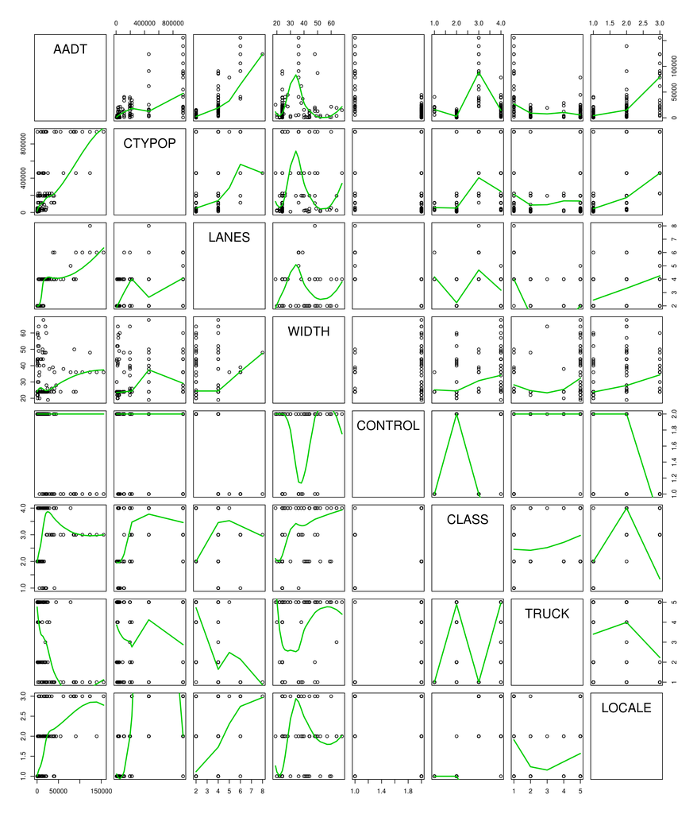

```r
library(car)
spm(.data, diagonal = "none", span = 0.75, reg.line = F, by.groups = TRUE)
```

## FIGURE 11.16 (p 467)

#### All-Possible-Regressions Output–MNDOT Traffic Estimation Example

Since the data was input with the qualitative variables as factor, `regsubsets` function will automatically split them into dummy variables. However, `vif` cannot account for the factors giving a different result than the book indicates, but it is still indicative nonetheless.

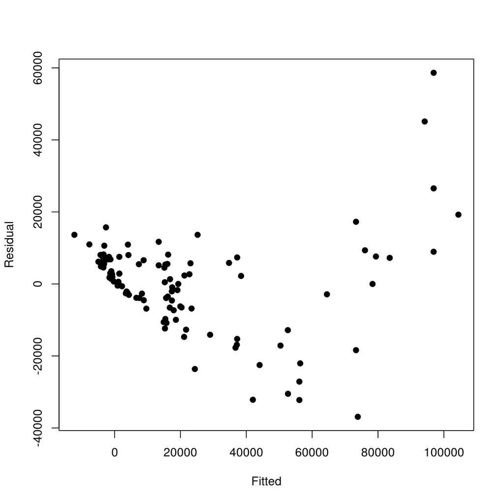

```r
library(leaps)
library(car)

# Some Mentioned Diagnostics
plot(resid(fit) ~ fitted(fit), xlab = "Fitted", ylab = "Residual", pch = 19)
```

```r
vif(fit)
```

```
##            GVIF Df GVIF^(1/(2*Df))
## CTYPOP    1.767  1           1.329
## LANES     2.751  1           1.658
## WIDTH     1.473  1           1.214
## CONTROL  24.549  1           4.955
## CLASS   492.832  3           2.810
## TRUCK     7.561  4           1.288
## LOCALE   24.127  2           2.216
```

```r
max(cooks.distance(fit), na.rm = TRUE)
```

```
## [1] 0.2076
```

```r
# Best Subsets Analysis
best <- regsubsets(formula(fit), .data, force.in = c(1, 2), nbest=5, nvmax = 7)
best$xnames <- paste("X", 0:13, sep = "")
with(summary(best), cbind(
    which[,-c(1:3)],
    Cp     = round(cp, 4),
    Rsq    = round(rsq, 4),
    AdjRsq = round(adjr2, 4)))
```

```
##   X3 X4 X5 X6 X7 X8 X9 X10 X11 X12 X13     Cp    Rsq AdjRsq
## 3  0  0  0  1  0  0  0   0   0   0   0  5.231 0.8045 0.7995
## 3  0  1  0  0  0  0  0   0   0   0   0 37.390 0.7514 0.7450
## 3  0  0  0  0  1  0  0   0   0   0   0 47.353 0.7349 0.7281
## 3  0  0  0  0  0  0  0   0   0   0   1 56.308 0.7201 0.7129
## 3  0  0  0  0  0  0  0   0   0   1   0 65.732 0.7045 0.6969
## 4  0  0  0  1  0  0  0   0   0   1   0  3.699 0.8104 0.8038
## 4  0  0  1  1  0  0  0   0   0   0   0  5.659 0.8071 0.8005
## 4  0  0  0  1  1  0  0   0   0   0   0  5.954 0.8066 0.8000
## 4  0  0  0  1  0  0  0   1   0   0   0  6.156 0.8063 0.7996
## 4  0  0  0  1  0  0  0   0   0   0   1  6.234 0.8062 0.7995
## 5  1  0  0  1  0  0  0   0   0   1   0  4.552 0.8123 0.8041
## 5  0  0  0  1  0  0  0   1   0   1   0  4.592 0.8122 0.8040
## 5  0  0  0  1  0  1  0   0   0   1   0  4.681 0.8120 0.8039
## 5  0  0  0  1  0  0  0   0   1   1   0  5.225 0.8111 0.8029
## 5  0  0  0  1  1  0  0   0   0   1   0  5.565 0.8106 0.8023
## 6  0  1  1  1  1  0  0   0   0   0   0  5.022 0.8148 0.8050
## 6  1  0  0  1  0  0  0   1   0   1   0  5.154 0.8146 0.8048
## 6  0  0  0  1  0  0  0   1   1   1   0  5.202 0.8145 0.8047
## 6  0  0  0  1  0  1  0   1   0   1   0  5.827 0.8135 0.8036
## 6  1  0  0  1  0  1  0   0   0   1   0  5.903 0.8133 0.8035
## 7  0  1  1  1  1  0  0   0   0   1   0  5.761 0.8169 0.8055
## 7  1  1  1  1  1  0  0   0   0   0   0  5.800 0.8168 0.8055
## 7  0  1  1  1  1  1  0   0   0   0   0  6.017 0.8165 0.8051
## 7  0  1  1  1  1  0  0   1   0   0   0  6.018 0.8164 0.8051
## 7  1  0  0  1  0  0  0   1   1   1   0  6.442 0.8157 0.8043
```

## BEST SUBSETS (p 468)

To collapse `CLASS2` and `CLASS4` into one group we need only change the levels attributed to those factors. In other words, we replace the level value for `CLASS2` to that for `CLASS4` as shown below.

The names for the pool of variables will go as follows:

```
   intercept         X0      CTYPOP            X1      LANES           X2
   CONTROL1          X3      CLASS1            X4      CLASS3          X5
   CTYPOP2           X6      LANES2            X7      CTYPOP:LANES    X8
   CTYPOP:CONTROL1   X9      CTYPOP:CLASS1     X10     CTYPOP:CLASS3   X11
   LANES:CONTROL1    X12     LANES:CLASS1      X13     LANES:CLASS3    X14
   CONTROL1:CLASS1   X15     CONTROL1:CLASS3   X16
```

```r
levels(.data$CLASS)[2] <- "4"
.data <- transform(.data,
  CTYPOP2 = scale(CTYPOP, T, F)^2,
  LANES2  = scale(LANES, T, F)^2)

pool <- AADT ~ (CTYPOP + LANES + CONTROL + CLASS)^2 + CTYPOP2 + LANES2
best <- regsubsets(pool, .data, force.in = c(1, 2), nbest = 5)
```

```
## Reordering variables and trying again:
```

```r
best$xnames <- paste("X", 0:16, sep = "")
with(summary(best), cbind(
    which[,-c(1:3)],
    Cp     = round(cp, 4),
    Rsq    = round(rsq, 4),
    AdjRsq = round(adjr2, 4)))
```

```
##   X3 X4 X5 X6 X7 X8 X9 X13 X10 X11 X14 X12 X15 X16      Cp    Rsq AdjRsq
## 3  0  0  0  0  0  0  1   0   0   0   0   0   0   0  65.554 0.8956 0.8929
## 3  0  0  0  0  0  0  0   0   1   0   0   0   0   0  74.711 0.8902 0.8874
## 3  0  0  0  0  0  0  0   1   0   0   0   0   0   0  79.860 0.8872 0.8843
## 3  0  0  0  0  0  0  0   0   0   0   0   1   0   0 159.749 0.8405 0.8364
## 3  0  0  0  0  0  1  0   0   0   0   0   0   0   0 194.316 0.8203 0.8157
## 4  0  0  0  0  1  0  1   0   0   0   0   0   0   0  19.029 0.9240 0.9213
## 4  0  0  0  0  1  0  0   0   1   0   0   0   0   0  30.072 0.9175 0.9147
## 4  0  0  0  0  1  0  0   1   0   0   0   0   0   0  33.726 0.9154 0.9125
## 4  0  0  0  0  0  1  0   0   1   0   0   0   0   0  41.339 0.9109 0.9079
## 4  0  0  0  0  0  1  0   1   0   0   0   0   0   0  41.940 0.9106 0.9075
## 5  0  1  0  0  0  0  0   0   1   1   0   0   0   0   8.139 0.9315 0.9285
## 5  0  0  1  0  0  0  1   0   0   0   0   1   0   0   9.479 0.9307 0.9277
## 5  0  0  0  0  1  0  1   0   1   0   0   0   0   0  10.787 0.9300 0.9269
## 5  0  1  0  0  0  0  0   1   0   1   0   0   0   0  11.023 0.9298 0.9268
```

[output cut: 21 more lines]

## FIGURE 11.17 (p 468)

#### Plots of Studentized Residuals versus Fitted Values–MNDOT Traffic Estimation Example

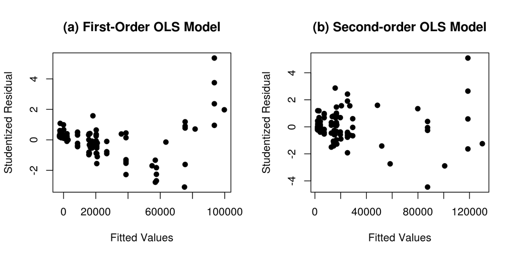

```r
par(mfrow = c(1, 2), pch = 19)

fit <- lm(AADT ~ CTYPOP + LANES + CONTROL + CLASS, .data)
plot(rstudent(fit) ~ fitted(fit), xlab = "Fitted Values", ylab = "Studentized Residual")
title("(a) First-Order OLS Model")

fit <- lm(AADT ~ CTYPOP + LANES + LANES2 + CONTROL + CTYPOP:CONTROL, .data)
plot(rstudent(fit) ~ fitted(fit), xlab = "Fitted Values", ylab = "Studentized Residual")
title("(b) Second-order OLS Model")
```

## FIGURE 11.18 (p 469)

#### Weighted Least Squares Regression Results–MNDOT Traffic Estimation Example

The weights can be extrated using the method used in `TABLE 11.1` above. The standard deviation function will just be modifed as the authors detail. The R values come out as the authors describe. They repeated this four times in all. The summaries show that the results (particularly for `CONTROL1`) do not come out the same at all (e.g., `CONTROL1` is negative).

```r
fit <- lm(AADT ~ CTYPOP + LANES + LANES2 + CONTROL + CTYPOP:CONTROL, .data)
summary(fit)  # Compare before iterations
```

```
##
## Call:
## lm(formula = AADT ~ CTYPOP + LANES + LANES2 + CONTROL + CTYPOP:CONTROL,
##     data = .data)
##
## Residuals:
##    Min     1Q Median     3Q    Max
## -32514  -2958   -705   2532  36775
##
## Coefficients:
##                     Estimate   Std. Error t value Pr(>|t|)
## (Intercept)     -17417.41036   4508.58883   -3.86  0.00019 ***
## CTYPOP               0.08079      0.00447   18.08  < 2e-16 ***
## LANES             6726.51683    946.81627    7.10  1.1e-10 ***
## LANES2            2349.44748    367.04996    6.40  3.5e-09 ***
## CONTROL2          3027.15100   3159.83420    0.96  0.34007
## CTYPOP:CONTROL2     -0.06926      0.00542  -12.79  < 2e-16 ***
## ---
## Signif. codes:  0 '***' 0.001 '**' 0.01 '*' 0.05 '.' 0.1 ' ' 1
##
## Residual standard error: 8480 on 115 degrees of freedom
## Multiple R-squared:  0.925,  Adjusted R-squared:  0.921
## F-statistic:  282 on 5 and 115 DF,  p-value: <2e-16
```

```r
w   <- fitted(lm(abs(resid(fit)) ~ CTYPOP + LANES, .data))^(-2)
fit <- update(fit, weights = w)                           # 1st iteration
w   <- fitted(lm(abs(resid(fit)) ~ CTYPOP + LANES, .data))^(-2)
fit <- update(fit, weights = w)                           # 2nd iteration
w   <- fitted(lm(abs(resid(fit)) ~ CTYPOP + LANES, .data))^(-2)
fit <- update(fit, weights = w)                           # 3nd iteration
w   <- fitted(lm(abs(resid(fit)) ~ CTYPOP + LANES, .data))^(-2)
fit <- update(fit, weights = w)                           # 4nd iteration

summary(fit)  # Compare after iterations
```

```
##
## Call:
## lm(formula = AADT ~ CTYPOP + LANES + LANES2 + CONTROL + CTYPOP:CONTROL,
##     data = .data, weights = w)
##
## Weighted Residuals:
##    Min     1Q Median     3Q    Max
## -2.809 -0.903 -0.248  0.667  6.965
##
## Coefficients:
##                     Estimate   Std. Error t value Pr(>|t|)
## (Intercept)     -13532.90760   4638.55715   -2.92   0.0042 **
## CTYPOP               0.07833      0.00785    9.98  < 2e-16 ***
## LANES             6155.26490    929.59608    6.62  1.2e-09 ***
## LANES2            2244.54362    751.89581    2.99   0.0035 **
## CONTROL2           218.58278   3364.41678    0.06   0.9483
## CTYPOP:CONTROL2     -0.06373      0.00842   -7.57  1.0e-11 ***
## ---
## Signif. codes:  0 '***' 0.001 '**' 0.01 '*' 0.05 '.' 0.1 ' ' 1
##
## Residual standard error: 1.4 on 115 degrees of freedom
## Multiple R-squared:  0.803,  Adjusted R-squared:  0.794
## F-statistic: 93.6 on 5 and 115 DF,  p-value: <2e-16
```

## FIGURE 11.19 (p 470)

#### Residual Plots for Final Weighted Least Squares Regression Fit–MNDOT Traffic Estimation Example

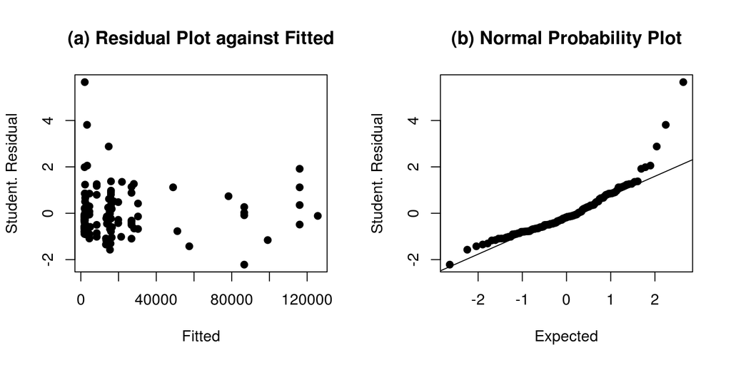

```r
par(mfrow = c(1, 2), pch = 19)
plot(rstudent(fit) ~ fitted(fit), xlab = "Fitted", ylab = "Student. Residual")
title("(a) Residual Plot against Fitted")

qqnorm(rstudent(fit), xlab = "Expected", ylab = "Student. Residual", main = "")
qqline(rstudent(fit))
title("(b) Normal Probability Plot")
```